# Live coding 8

Andrew Irwin

2021-03-04 8:35

# Agenda

- Questions arising from lessons, tasks
- Team work and term project update
- PCA, MDS, k-means

The plan for the live coding is for us to work together to solve problems using tools from this week’s lessons. The skills from this week are about collaborating, finding data, and writing reports. These skills will all be essential for your term project.

Today I will work through examples

- dimension reduction using PCA to rotate and project data
- converting distances into locations on a plane (MDS)
- clustering observations based on distance in many dimensions (k-means)

**Note**:

There will no new tasks *next week* to give you more time to work on the project proposal, which is due next Friday 12 March.

```r
tuesdata <- tidytuesdayR::tt_load('2020-10-27')
```

```
## --- Compiling #TidyTuesday Information for 2020-10-27 ----
```

```
## --- There is 1 file available ---
```

```
## --- Starting Download ---
```

```
## --- Download complete ---
```

```r
wind_turbines <- tuesdata$`wind-turbine`
```

Let’s look at the data available.

```r
skimr::skim(wind_turbines)
```

Data summary

| Name | wind_turbines |
| --- | --- |
| Number of rows | 6698 |
| Number of columns | 15 |
| _______________________ |  |
| Column type frequency: |  |
| character | 8 |
| numeric | 7 |
| ________________________ |  |
| Group variables | None |

**Variable type: character**

| skim_variable | n_missing | complete_rate | min | max | empty | n_unique | whitespace |
| --- | --- | --- | --- | --- | --- | --- | --- |
| province_territory | 0 | 1.00 | 5 | 25 | 0 | 12 | 0 |
| project_name | 1 | 1.00 | 5 | 41 | 0 | 268 | 0 |
| turbine_identifier | 0 | 1.00 | 4 | 6 | 0 | 6683 | 0 |
| turbine_number_in_project | 0 | 1.00 | 3 | 7 | 0 | 4300 | 0 |
| manufacturer | 0 | 1.00 | 2 | 24 | 0 | 23 | 0 |
| model | 0 | 1.00 | 3 | 12 | 0 | 92 | 0 |
| commissioning_date | 0 | 1.00 | 4 | 14 | 0 | 35 | 0 |
| notes | 6064 | 0.09 | 20 | 196 | 0 | 27 | 0 |

**Variable type: numeric**

| skim_variable | n_missing | complete_rate | mean | sd | p0 | p25 | p50 | p75 | p100 | hist |
| --- | --- | --- | --- | --- | --- | --- | --- | --- | --- | --- |
| objectid | 0 | 1.00 | 3349.50 | 1933.69 | 1.00 | 1675.25 | 3349.50 | 5023.75 | 6698.00 | ▇▇▇▇▇ |
| total_project_capacity_mw | 0 | 1.00 | 134.76 | 90.50 | 0.30 | 70.50 | 102.00 | 181.50 | 350.00 | ▆▇▅▂▂ |
| turbine_rated_capacity_k_w | 220 | 0.97 | 1967.31 | 605.93 | 65.00 | 1600.00 | 1880.00 | 2300.00 | 3750.00 | ▁▃▇▅▁ |
| rotor_diameter_m | 0 | 1.00 | 88.62 | 16.45 | 15.00 | 80.00 | 90.00 | 100.00 | 141.00 | ▁▁▇▇▁ |
| hub_height_m | 0 | 1.00 | 83.34 | 14.44 | 24.50 | 80.00 | 80.00 | 92.00 | 132.00 | ▁▂▇▃▁ |
| latitude | 0 | 1.00 | 46.76 | 3.27 | 42.00 | 43.98 | 46.67 | 49.17 | 64.49 | ▇▇▁▁▁ |
| longitude | 0 | 1.00 | -83.03 | 17.59 | -135.23 | -84.41 | -80.67 | -67.85 | -52.97 | ▁▂▁▇▅ |

Make a nice report about the data.

```r
glimpse(wind_turbines)
```

```
## Rows: 6,698
## Columns: 15
## $ objectid                   <dbl> 1, 2, 3, 4, 5, 6, 7, 8, 9, 10, 11, 12, 13, …
## $ province_territory         <chr> "Alberta", "Alberta", "Alberta", "Alberta",…
## $ project_name               <chr> "Optimist Wind Energy", "Castle River Wind …
## $ total_project_capacity_mw  <dbl> 0.90, 44.00, 3.78, 3.78, 3.78, 3.78, 19.50,…
## $ turbine_identifier         <chr> "OWE1", "CRW1", "WWT1", "WWT2", "WWT3", "WW…
## $ turbine_number_in_project  <chr> "1/2", "1/60", "1/6", "2/6", "3/6", "4/6", …
## $ turbine_rated_capacity_k_w <dbl> 150, 600, 600, 600, 600, 660, 1300, 1300, 1…
## $ rotor_diameter_m           <dbl> 23, 44, 44, 44, 44, 47, 60, 60, 60, 60, 60,…
## $ hub_height_m               <dbl> 30, 40, 50, 50, 50, 50, 46, 46, 46, 46, 46,…
## $ manufacturer               <chr> "Bonus", "Vestas", "Vestas", "Vestas", "Ves…
## $ model                      <chr> "AN 150/30", "V44/600", "V44/600", "V44/600…
## $ commissioning_date         <chr> "1993", "1997", "1998", "1998", "1998", "20…
## $ latitude                   <dbl> 49.52535, 49.51264, 49.23307, 49.23303, 49.…
## $ longitude                  <dbl> -114.0548, -114.0357, -113.6549, -113.6302,…
## $ notes                      <chr> NA, NA, NA, NA, NA, NA, NA, NA, NA, NA, NA,…
```

And another

```r
dlookr::diagnose(wind_turbines)
```

```
## # A tibble: 15 x 6
##    variables       types  missing_count missing_percent unique_count unique_rate
##    <chr>           <chr>          <int>           <dbl>        <int>       <dbl>
##  1 objectid        numer…             0          0              6698     1
##  2 province_terri… chara…             0          0                12     0.00179
##  3 project_name    chara…             1          0.0149          269     0.0402
##  4 total_project_… numer…             0          0               154     0.0230
##  5 turbine_identi… chara…             0          0              6683     0.998
##  6 turbine_number… chara…             0          0              4300     0.642
##  7 turbine_rated_… numer…           220          3.28             48     0.00717
##  8 rotor_diameter… numer…             0          0                42     0.00627
##  9 hub_height_m    numer…             0          0                42     0.00627
## 10 manufacturer    chara…             0          0                23     0.00343
## 11 model           chara…             0          0                92     0.0137
## 12 commissioning_… chara…             0          0                35     0.00523
## 13 latitude        numer…             0          0              6687     0.998
## 14 longitude       numer…             0          0              6690     0.999
## 15 notes           chara…          6064         90.5              28     0.00418
```

## Exploratory plots

Make a scatterplot of the quantitative variables.

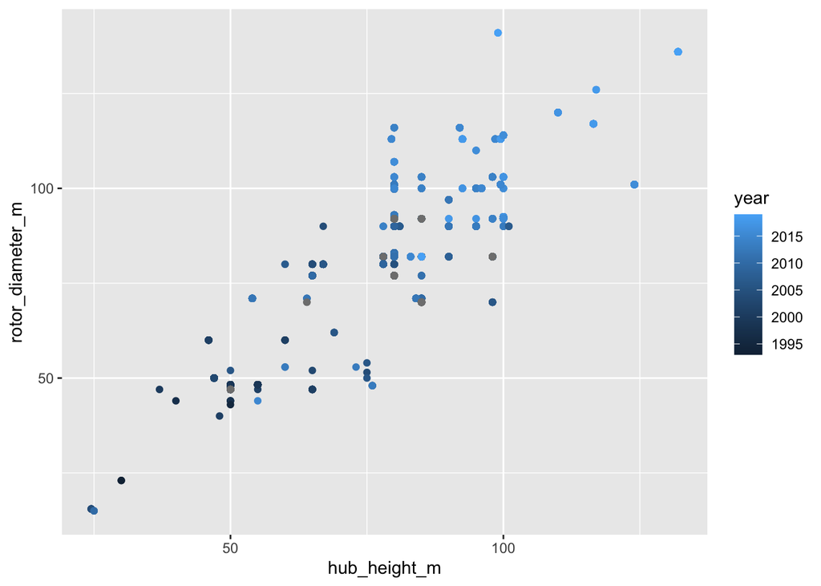

```r
wind_turbines %>% mutate(year = as.numeric(commissioning_date)) %>%
  ggplot(aes(x = hub_height_m, y = rotor_diameter_m, color = year)) +
  geom_point()
```

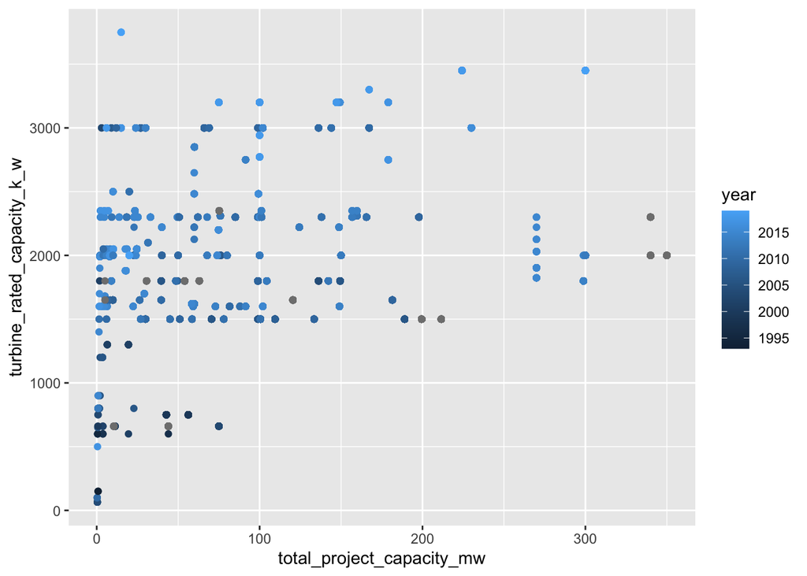

```r
wind_turbines %>% mutate(year = as.numeric(commissioning_date)) %>%
  ggplot(aes(x = total_project_capacity_mw, y = turbine_rated_capacity_k_w, color = year)) +
  geom_point()
```

## PCA

Make a PCA of the quantitative variables. Use `prcomp`. Experiment with scale=FALSE and scale=TRUE.

```r
wind_turbines_no_na <- wind_turbines %>% filter(!is.na(total_project_capacity_mw + turbine_rated_capacity_k_w +
                                                         hub_height_m + rotor_diameter_m))
wind_ss <- wind_turbines_no_na %>% select( # total_project_capacity_mw,
  turbine_rated_capacity_k_w, hub_height_m, rotor_diameter_m)
pca1 <- prcomp(wind_ss, scale=TRUE)
```

Use `autoplot` to make a biplot. Fix the code cut and pasted from the course notes.

```r
autoplot(pca1, data= wind_turbines_no_na, loadings=TRUE, loadings.label=TRUE, scale=1) # + coord_equal()
```

[output not shown]

Get the “principal components” using `augment`. Fix the code cut and pasted from the notes.

```r
pca1 %>%
  augment(wind_turbines_no_na) %>%
  ggplot(aes(x=.fittedPC1, y= .fittedPC2)) +
  geom_point()
```

[output not shown]

## MDS

```r
wind_ss_d <- distinct(wind_ss)  # there are a lot of identical observations when we just look at these variables
dM <- dist(scale(wind_ss_d))
# dM
```

Use `cmdscale` to perform MDS on the distance matrix.

```r
mds1 <- cmdscale(dM)
```

Turn the result into a tibble and plot.

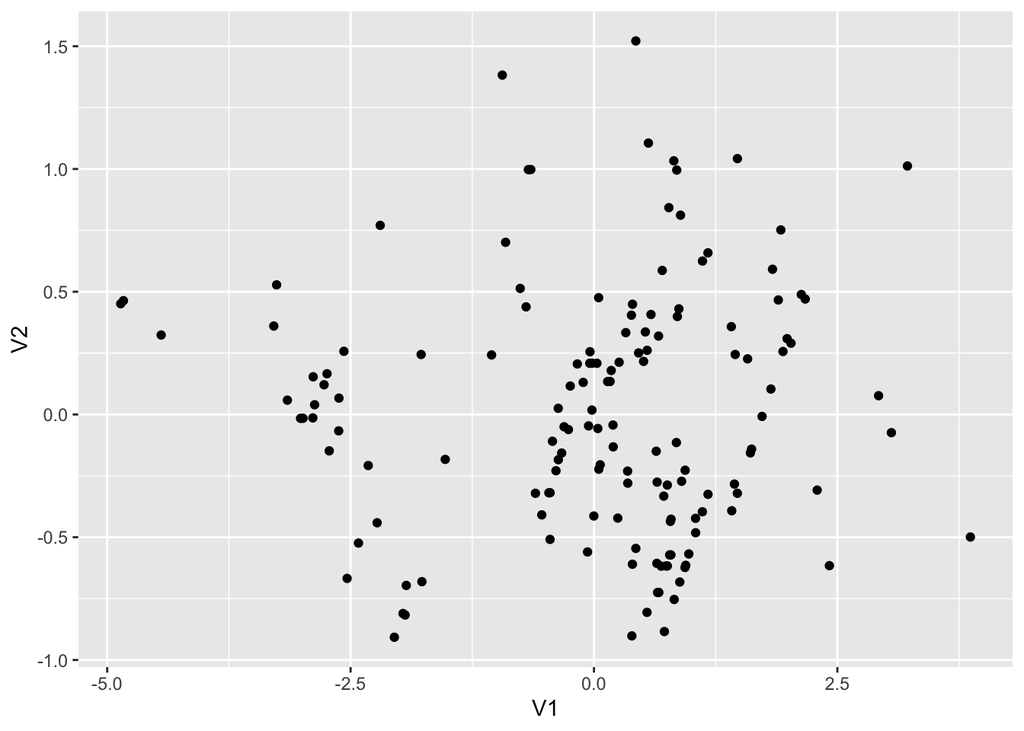

```r
mds1 %>% as_tibble()  %>% ggplot(aes(V1, V2)) + geom_point()
```

## k-means

Cluster the turbines based on quantitative variables. Scaled and not-scaled. Use `kmeans`.

```r
# km1 <- kmeans(distinct(wind_ss), 4)
km1 <- kmeans(scale(wind_ss), 4)
```

Use `tidy` to show the clusters.

```r
tidy(km1)
```

```
## # A tibble: 4 x 6
##   turbine_rated_capacity_k… hub_height_m rotor_diameter_m  size withinss cluster
##                       <dbl>        <dbl>            <dbl> <int>    <dbl> <fct>
## 1                    -0.426       -0.300           -0.578  2376     927. 1
## 2                    -2.08        -2.26            -2.42    421     182. 2
## 3                     0.213        0.146            0.414  2945    2488. 3
## 4                     1.71         1.67             1.59    736    1175. 4
```

Use `augment` on the result and combine with the original data frame. Make a plot of clusters and show some other categorical data.

```r
augment(km1, wind_turbines_no_na)
```

```
## # A tibble: 6,478 x 16
##    objectid province_territo… project_name    total_project_ca… turbine_identif…
##       <dbl> <chr>             <chr>                       <dbl> <chr>
##  1        1 Alberta           Optimist Wind …              0.9  OWE1
##  2        2 Alberta           Castle River W…             44    CRW1
##  3        3 Alberta           Waterton Wind …              3.78 WWT1
##  4        4 Alberta           Waterton Wind …              3.78 WWT2
##  5        5 Alberta           Waterton Wind …              3.78 WWT3
##  6        6 Alberta           Waterton Wind …              3.78 WWT4
##  7        7 Alberta           Cowley North                19.5  CON1
##  8        8 Alberta           Cowley North                19.5  CON2
##  9        9 Alberta           Cowley North                19.5  CON3
## 10       10 Alberta           Cowley North                19.5  CON4
## # … with 6,468 more rows, and 11 more variables:
## #   turbine_number_in_project <chr>, turbine_rated_capacity_k_w <dbl>,
## #   rotor_diameter_m <dbl>, hub_height_m <dbl>, manufacturer <chr>,
## #   model <chr>, commissioning_date <chr>, latitude <dbl>, longitude <dbl>,
## #   notes <chr>, .cluster <fct>
```

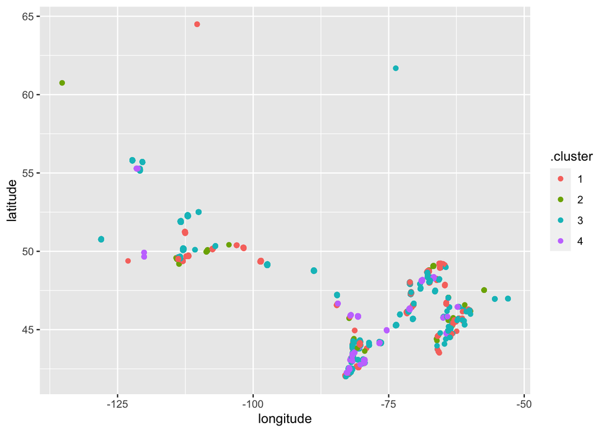

```r
augment(km1, wind_turbines_no_na) %>% ggplot(aes(longitude, latitude, color=.cluster)) + geom_point()
```